# Good Plot, Bad Plot

Keanu Rochette

2024-10-29

# Load the Libraries

```r
library(tidyverse)
library(here)
library(ghibli)
library(ggrepel)
library(RColorBrewer)
library(magick)
library(patchwork)
library(graphics)
library(grid)
library(gganimate)
```

# Load the Data

```r
chem <- read_csv(here("Badplot_Goodplot", "data", "chemicaldata_maunalua.csv"))
```

# Let’s make a **bad** plot

## Creating a table summary to later plot it.

For this data table, I calculated the overall yearly average of all biogeochemical parameter.  
Then, I clustered the data by parameters and calculated the average of each parameter by season and by zone.  
Then I calculated the difference of the season average of each parameters compared to the overall average.  
The idea was to calculate something that resembles calculating **anomalies** in climate studies.

```r
chem_summary <- chem %>%
  #pivoting longer so the biogeochem measurements are in one column
  pivot_longer(cols = c(Temp_in:percent_sgd),
               names_to = "Parameters",
               values_to = "Values")%>%
  # the channel zone had to many NAs so I removed it
  filter(Zone != "Channel") %>%
group_by(Parameters) %>%
  # calculate the yearly average of each parameters
  mutate(average = mean(Values, na.rm = T)) %>% ungroup() %>%
  group_by(Season, Parameters, Zone) %>%
  #now calculating the average by parameter, season and sample zones
  summarize(dist_mean = mean(Values, na.rm = T)-average) %>%
  # there were many repeats at the end
  distinct() %>%
  drop_na()
```

## Making seasonal plots

My original idea was to make a seasonal plot using facet_wrap().  
However, I also went to add an image representative of the seasons (fall and spring). Unfortunately, I couldn’t figure out how to do it with a faceted graph, so I decided to do separate graphs, add the images individually and then, merge them with *Patchwork*.

### Fall plot

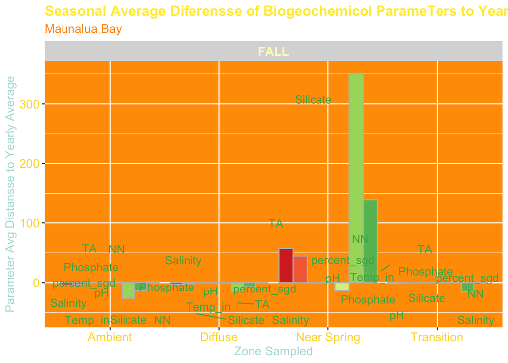

```r
fall_bplot <- chem_summary %>%
  filter(Season == "FALL") %>% # only keeping the fall data
ggplot(aes(x= Zone, y = dist_mean, label= Parameters)) +
  # creating the bar chart
  geom_bar(aes(fill = factor(Parameters)),
           stat = "identity",
           position = position_dodge(width = 0.9),
           color = "grey", face = "bold") +
  # Adding labels but avoiding overlaps in the labels
  geom_text_repel(size = 4, position= position_jitter(width=0.5, height=60),
                  color = "#4CAF50") +
  # Creating the facet wrap appearance for future merging
  facet_wrap(~Season, ncol = 2) +
  # Aesthetic elements of the plot
  labs(title = "Seasonal Average Diferensse of Biogeochemicol ParameTers to Yearly Average in an SGD Zone in the state of Hawaii",
       subtitle = "Maunalua Bay",
       x = "Zone Sampled",
       y = "Parameter Avg Distansse to Yearly Average",
       fill = "P@raMeTers") +
  theme_grey() +
  theme(plot.title = element_text(size=14, face = "bold", color = "#FFEB3B"),
        plot.subtitle = element_text(size=12, color = "#FF991C"),
        axis.title = element_text(size = 12, color = "#B2DFDB"),
        axis.text = element_text(size = 12, color = "#FDD835"),
        strip.text.x = element_text(size = 12, face = "bold", color = "#FFF9C4"),
        panel.background = element_rect(fill = "#FF9D00"),
        legend.position="none") +
  #choosing a color palette that is not optimal
  scale_fill_brewer(palette= "RdYlGn")

fall_bplot
```

### Spring Plot

This plot is essentially the same as the previous one by for spring data

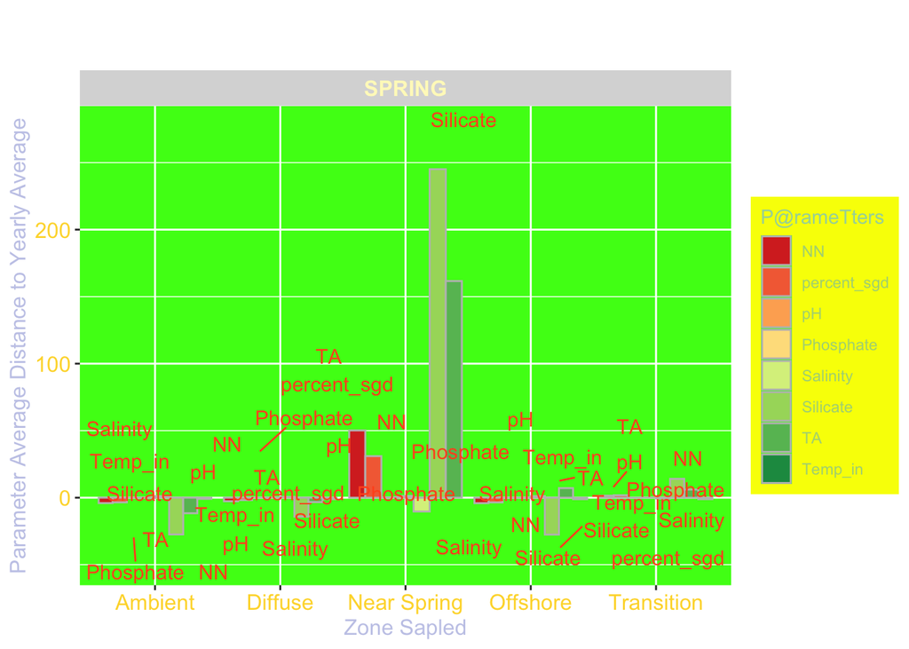

```r
spring_bplot <- chem_summary %>%
  filter(Season == "SPRING") %>%
ggplot(aes(x= Zone, y = dist_mean, label= Parameters)) +
  geom_bar(aes(fill = factor(Parameters)),
           stat = "identity",
           position = position_dodge(width = 0.9),
           color = "grey") +
  geom_text_repel(size = 4, position= position_jitter(width=0.5,height=50),
                  color = "#FF5722", face = "bold") +
  facet_wrap(~Season, ncol = 2) +
  labs(title = " ",
       subtitle = " ",
       x = "Zone Sapled",
       y = "Parameter Average Distance to Yearly Average",
       fill = "P@rameTters") +
  theme_grey() +
  theme(axis.title = element_text(size = 12, color = "#C5CAE9"),
        axis.text = element_text(size = 12, color = "#FDD835"),
        strip.text.x = element_text(size = 12, color = "#FFF9C4",
                                    face = "bold"),
        panel.background = element_rect(fill = "#45FF17"),
        legend.background = element_rect(fill = "#F7FF00"),
        legend.title = element_text(color="#A5D6A7"),
        legend.text=element_text(color = "#AED581")) +
  scale_fill_brewer(palette= "RdYlGn")

spring_bplot
```

## Adding images to the plots

```r
leaf <- image_read("https://st2.depositphotos.com/1821481/5451/i/450/depositphotos_54517857-stock-photo-autumn-leaf.jpg")

daisy <- image_read("https://img.freepik.com/premium-photo/one-white-daisy-flower-isolated-white-background-flat-lay-top-view-floral-pattern-object_438009-5164.jpg?w=360")
```

## Converting the images in rasters

Not entirely sure what a raster is but, my understanding is that the images where converted into their pixels so that they can be mapped later on a grid.

```r
gleaf <- rasterGrob(leaf, width = unit(1, "npc"), height = unit(1, "npc"))
gdaisy <- rasterGrob(daisy, width = unit(1, "npc"), height = unit(1, "npc"))
```

## Merging all the elements to make the final plot

We are using Magick and Patchwork here. - Magick is used to add the raster images to the individual plots. - Patchwork allows to merge the fall and spring plots in one figure with their images on it.

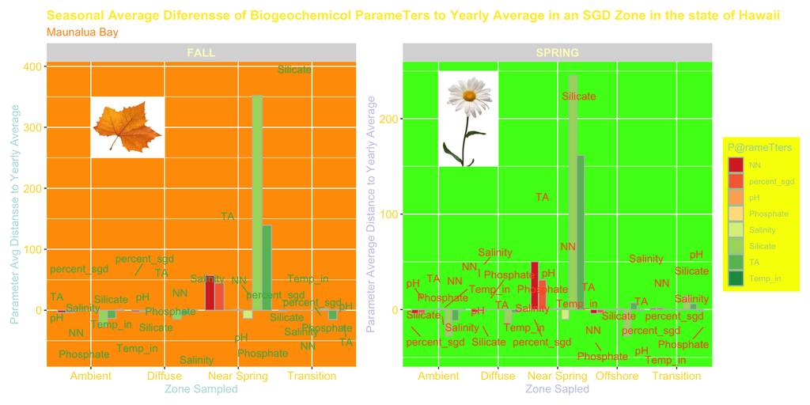

```r
(fall_bplot +
  annotation_custom(gleaf, xmin = 1, xmax = 2, ymin = 250, ymax = 350)) +
  (spring_bplot +
  annotation_custom(gdaisy, xmin = 1, xmax = 2, ymin = 150, ymax = 250))
```

## Why is this a *bad plot*?

- **Labels**: labels on the graphs are unnecessary, overwhelming and make it difficult to read the graph.
- **Color Palette** of the bar chart: the color ramp from green to red is not ideal for people with have colorblindness as those colors do not provide enough contrast to distinguish them clear. This makes ready the plot more difficult.
- **Background colors**: the background colors were supposed to echo the season that is represented on the graph. However, the orange (fall) and green (spring) are the similar colors to those used for the color ramp. So, it makes reading the graph very difficult and it’s even more difficult for the color blind demographic.
- **Text colors**: The text color is not uniform, too many colors are represented on the plot making it overwhelming to the viewer. The colors of the text are close to the background color and not colorblind friendly, making the plot hard to read.  
  The axis text, titles and strip text are light in color and don’t contrast enough with the white background.  
  The legend was plotted in a bright yellow color and just echoes the loudness of the plots. The text of the legend is very light which is hard to read on a yellow background.  
  Overall, the color on not ideal as they overwhelm the viewer and require additional focus to try understanding the plot.
- **Images** : the images in the corner are meant to echo and visually represent the seasons plotted on the graph. However, it was complicated to get to that result… So a waste of time. They are redundant as 2 other elements (facet titles and background color) are meant to show the seasons on this plot. They only crowd the plot more, overwhelming the viewer which makes it more difficult to easily read the information presented on the graph.
- **Grid**: this theme shows a white grid that contrast with the background color and make the plot appear overall more busy.
- **Axes**: the axes are the not the same and it’s hard to compare the data by season.
- **Spelling**: There are typos throughout the plot.
- **Analytic method**: not the best to study changes by seasons.
- *Redeaming quality*: It’s not a 3D plot! Only because I couldn’t figure out how to do it…

Like the Gen Zs say:

> “It’s not giving…”

# Let’s make a **Good** Plot

## Ordering my factors

I want to know the order of the Zones, i.e., which one is closed to the shore and which one is fardest.

```r
chem %>% select(Zone, Lat, Long) %>%
  drop_na() %>%
  group_by(Zone) %>%
  summarise(Lat = min(Lat), Long = min(Long)) %>%
  arrange(Long)
```

```
## # A tibble: 6 × 3
##   Zone          Lat  Long
##   <chr>       <dbl> <dbl>
## 1 Near Spring  21.3 -158.
## 2 Transition   21.3 -158.
## 3 Diffuse      21.3 -158.
## 4 Ambient      21.3 -158.
## 5 Offshore     21.3 -158.
## 6 Channel      21.3 -158.
```

## Plotting the nice plot

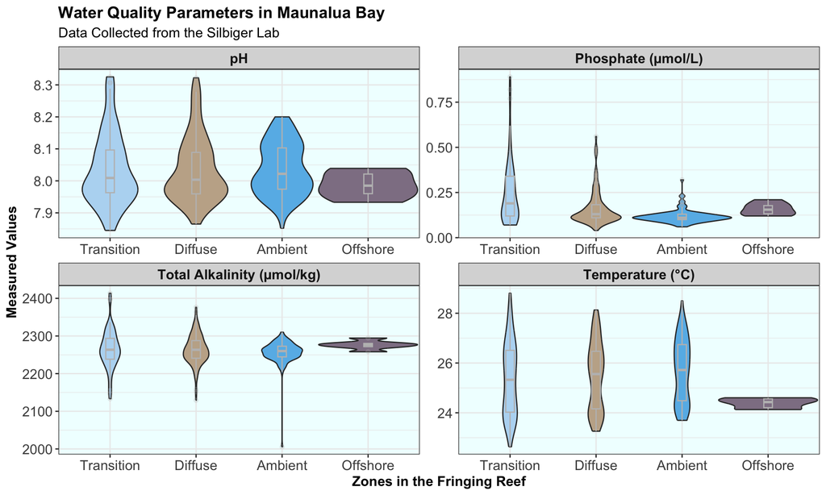

```r
chem %>%
  #pivoting longer so the biogeochem measurements are in one column
  pivot_longer(cols = c(Temp_in:percent_sgd),
               names_to = "Parameters",
               values_to = "Values")%>%
  # channel and near spring zone had too many NAs so I removed them for visuals
  filter(Zone != "Channel", Zone != "Near Spring") %>%
  # I'm making a violin plot, parameters that are highly variables will not render nicely so I am only keeping parameters vary less.
  filter(Parameters == "TA"| Parameters == "Phosphate"|Parameters == "pH" |
         Parameters == "Temp_in") %>%
  #Ordering the zones from shore to ocean.
  mutate(Zone = factor(Zone, levels= c("Transition", "Diffuse","Ambient", "Offshore"))) %>%
  ggplot(aes(x= Zone, y= Values, fill = Zone)) +
  #making violin plots as my primary geometry
  geom_violin(width=1.15)+
  #adding box plots as secondary geometry inside the violin plots to add more information to the graph
  geom_boxplot(width=0.1, color="grey", alpha=0.2)+
  # splitting the data by parameters with free scales because the measurememts are not in the same unit.
  # Also relabeling the strip text
  facet_wrap(~ Parameters, scale= "free", nrow = 2,
       labeller = labeller(Parameters= c(
          "Phosphate" ="Phosphate (µmol/L)",
          "TA" = "Total Alkalinity (µmol/kg)",
          "Temp_in" = "Temperature (°C)"))) +
  #add nicer labels
  labs(title = "Water Quality Parameters in Maunalua Bay",
       subtitle = "Data Collected from the Silbiger Lab",
       x = "Zones in the Fringing Reef",
       y = "Measured Values"
       )+
  theme_bw() +
  theme(plot.title = element_text(size=14, face = "bold"),
        plot.subtitle = element_text(size=12),
        axis.title = element_text(size = 12, face = "bold"),
        axis.text = element_text(size = 12),
        strip.text.x = element_text(size = 12, face = "bold"),
        legend.title=element_text(size=12, face = "bold"),
        legend.text=element_text(size=12),
        axis.text.x = element_text(),
        panel.background = element_rect(fill = "azure1"),
        legend.position = "none")+
  #custom colors
  scale_fill_ghibli_d("SpiritedMedium", direction=-1)
```

## Why is it a *good plot*?

- **Title and Subtitle**: They are short and simple, providing only the necessary information to the viewer. The bolded title stands out from the subtitle.
- **Axis title and text**: They are sized correctly, clean and only convey necessary information. The axis are not the same across the plots, however it make sense since they are not displaying the same information.
- **Facet wrap**: the plot is facets by selected measurements. Only the measurements that made sense were selected to be plotted. They are bolded for clarity and show the units in which the measurements can be read so there is no confusing.
- **Analytical method**: the primary geometry is a violin plot which is meant to show the density distribution of the data. We added a box plot in the violin plots such that box plots are fairly discreet. They provide additional information such as the quantiles and the median of the data.
- **Color palette**: the colors selected come from the ghibli package. They are high contrast with each other and the background so it’s easy to read the plot. The cooler pastel tones make are also typically more relaxing to look at than loud bright neon colors.
- **Background color**: The very light blue background adds a nice touch of color to the plot without being obnoxiously loud and crowding the plot.
- **Zone Order**: The sampling zones where ordered from shore to ocean to make the data easily readable. Patterns and differences from shore to ocean will also be more noticeable that way.
- **Figure Legend**: The legend was omitted because it was redundant and not useful here.
- **Spelling**: There were efforts to remove any typos from the final plots.